# Reproducibility Paper

Haley Dunleavy

Yogi Bear

10/11/2019

# Abstract

# Introduction

Writing reports and academic papers is a ton of work but a large amount of that work can be spent doing monotonous tasks such as:

- Updating figures and tables as we refine our analysis
- Editing our analysis and, in turn, editing our paper’s text
- Managing bibliography sections and in-text citations/references

These monotonous tasks are also highly error-prone. With RMarkdown, we can close the loop, so to speak, between our analysis and our manuscript because the manuscript can become the analysis.

As an alternative to Microsoft Word, RMarkdown provides some advantages:

- Free to use
- Uses text so we can:
  - Use version control for
    - Tracking changes
    - Collaborating
  - Edit it with our favorite and most powerful text editors
  - Use the command line to for automation

The rest of this document will show how we get some of the features we need such as:

- Attractive typesetting for mathematics
- Figures, tables, and captions
- In-text citations
- Bibliographies

# Methods

Our analysis will be pretty simple. We’ll use the `diamonds` dataset from the `ggplot2` (Wickham 2009) package and run a simple linear model. At the top of this document, we started with a code chunk with `echo=FALSE` set as a chunk option so that we can load the `ggplot2` package and `diamonds` dataset without outputting anything to the screen.

For our analysis, we’ll create a really great plot which really shows the relationship between price and carat and shows how we include plots in our document. Then we’ll run a linear model of the form
$$\int_{x = 1}^{N}mx + bdx$$
on the relationship between price and carat and shows how we include tables in our document. We can also put some more advanced math in our paper and it will be beautifully typeset:

$$\sum_{i=1}^{N}{log(i) + \frac{\omega}{x}}$$

# Results

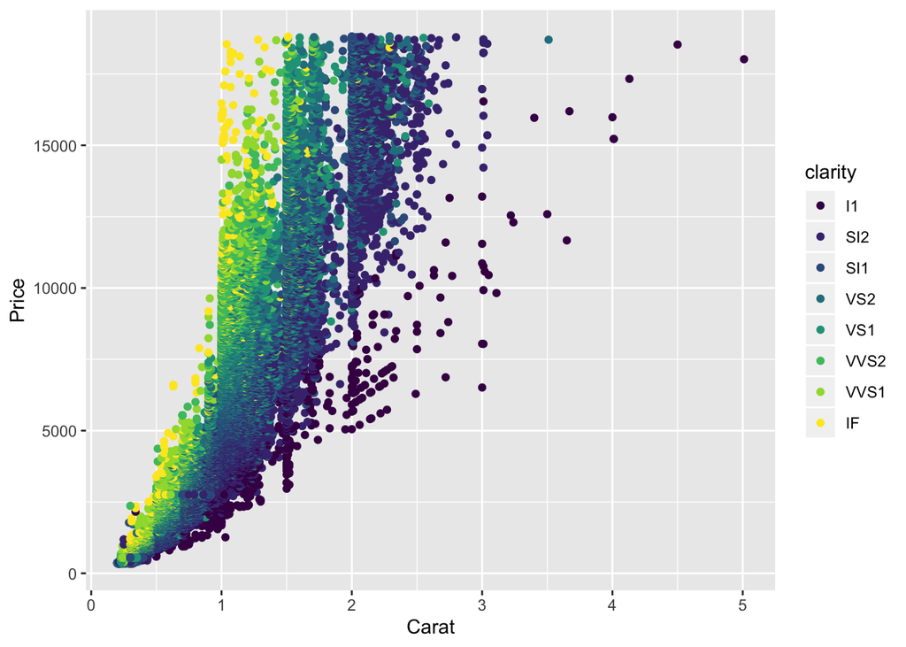

And do some analysis:

| term | estimate | std.error | statistic | p.value |
| --- | --- | --- | --- | --- |
| (Intercept) | -2256.36 | 13.06 | -172.83 | 0 |
| carat | 7756.43 | 14.07 | 551.41 | 0 |

We were delighted to find that the slope parameter was 7756.43.

# Discussion

# References

R Core Team. 2015. “R: A Language and Environment for Statistical Computing.” http://www.r-project.org.

Wickham, Hadley. 2009. *Ggplot2: Elegant Graphics for Data Analysis*. Springer-Verlag New York. http://ggplot2.org.